# Properties of matrices 行列の特徴

# 8 Exercise 3

## 8.1 Exercise 3-1

2変量正規分布において、各変数の分散を(1,1)からずらして、乱点を発生せよ。 なお、分散共分散行列は対角行列のままとする。

```
## [1]  9.462167e-03 -4.070587e-05
```

```
## [1] 0.9951902 0.1943384
```

```
##             [,1]        [,2]
## [1,]  0.99519020 -0.00308122
## [2,] -0.00308122  0.19433838
```

```
##           [,1]      [,2]
## [1,] 0.9861931 0.0000000
## [2,] 0.0000000 0.1943617
```

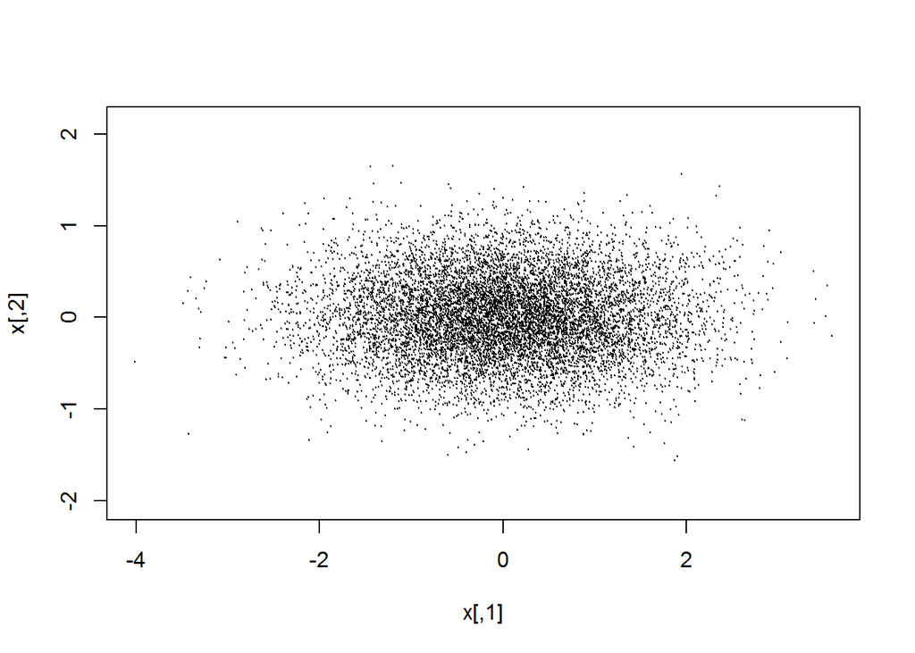

## Exercise 3-2

4-1で用いたSigmaと相似な行列で対称なものは正定値行列であるから、mvtnorm::rmvnorm()のsigma引数として適当なはずである。

そのようなsigmaを作り、乱点を発生せよ。

```r
R <- Random.Start(d)
sigma3 <- R %*% sigma2 %*% t(R)
x <- rmvnorm(n=n,mean=m,sigma=sigma3)
apply(x,2,mean)
```

```
## [1]  0.004337685 -0.004068588
```

```r
apply(x,2,var)
```

```
## [1] 0.2968694 0.8813722
```

```r
round(cov(x),8)
```

```
##            [,1]       [,2]
## [1,]  0.2968693 -0.2644093
## [2,] -0.2644093  0.8813722
```

```r
sigma3
```

```
##            [,1]       [,2]
## [1,]  0.2928167 -0.2612783
## [2,] -0.2612783  0.8877382
```

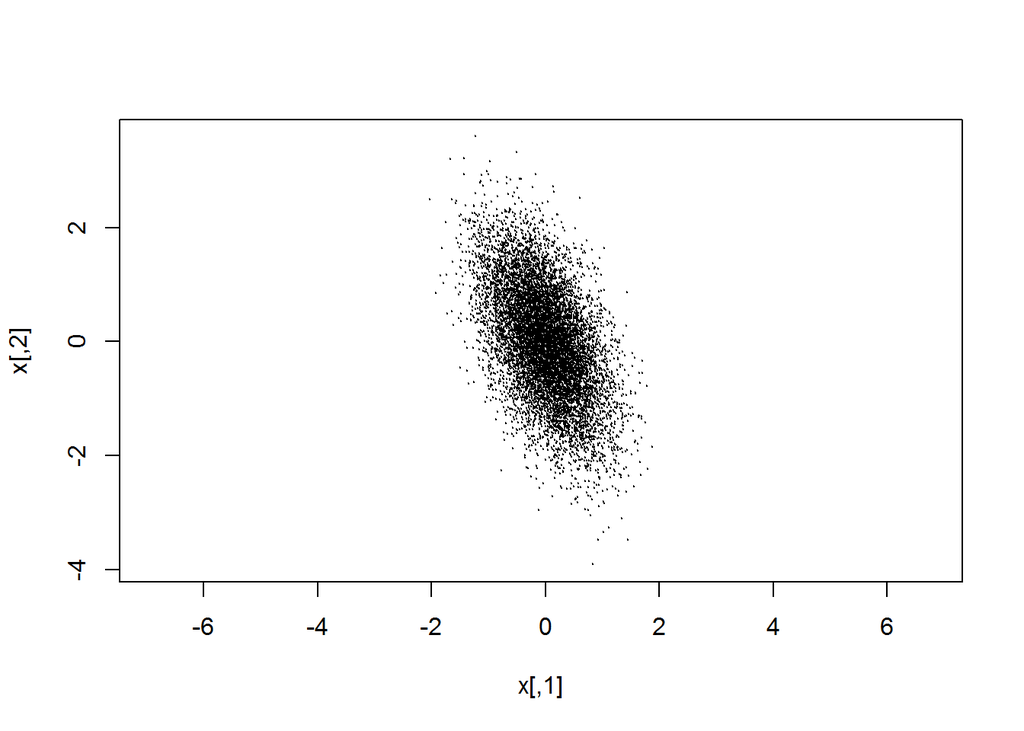

```r
plot(x,asp=TRUE,pch=20,cex=0.1)
```

## 8.2 Exercise 3-3

分散共分散行列を $R J R^{-1}$にて変換すると、乱点分布が回転し、楕円の軸が斜めになった。

実際、分散共分散行列の変換に用いた直交行列$R$を利用して、乱点を変換すると、楕円の軸を正すことができる。

以下のコードを読み、変換した分散共分散行列に従う２変量正規分布の軸が補正されていることを、コードの各行の処理にコメントを加えることで確認せよ。

```r
R <- Random.Start(d)
sigma3 <- R %*% sigma2 %*% t(R)
x <- rmvnorm(n=n,mean=m,sigma=sigma3)
apply(x,2,mean)
```

```
## [1] 0.007693247 0.010971247
```

```r
apply(x,2,var)
```

```
## [1] 0.9831017 0.1957530
```

```r
cov(x)
```

```
##             [,1]        [,2]
## [1,]  0.98310167 -0.02002558
## [2,] -0.02002558  0.19575299
```

```r
round(cov(x),8)
```

```
##             [,1]        [,2]
## [1,]  0.98310167 -0.02002558
## [2,] -0.02002558  0.19575299
```

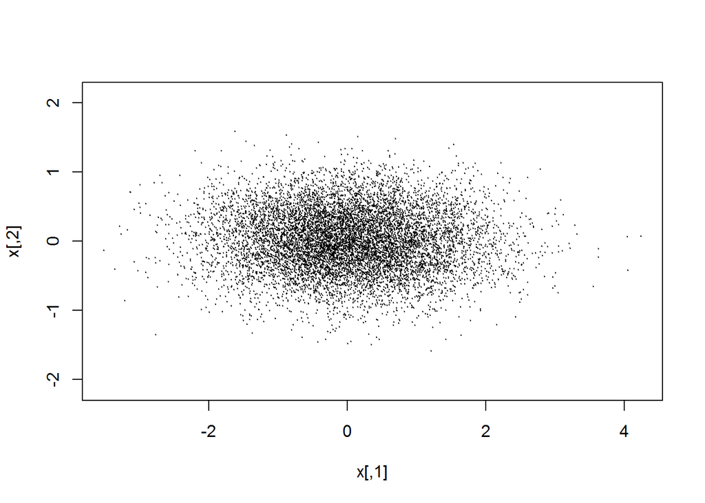

```r
plot(x,asp=TRUE,pch=20,cex=0.1)
```

```r
x2 <- t(t(R) %*% t(x))
cov(x2)
```

```
##              [,1]         [,2]
## [1,] 0.9836103474 0.0005076271
## [2,] 0.0005076271 0.1952443077
```

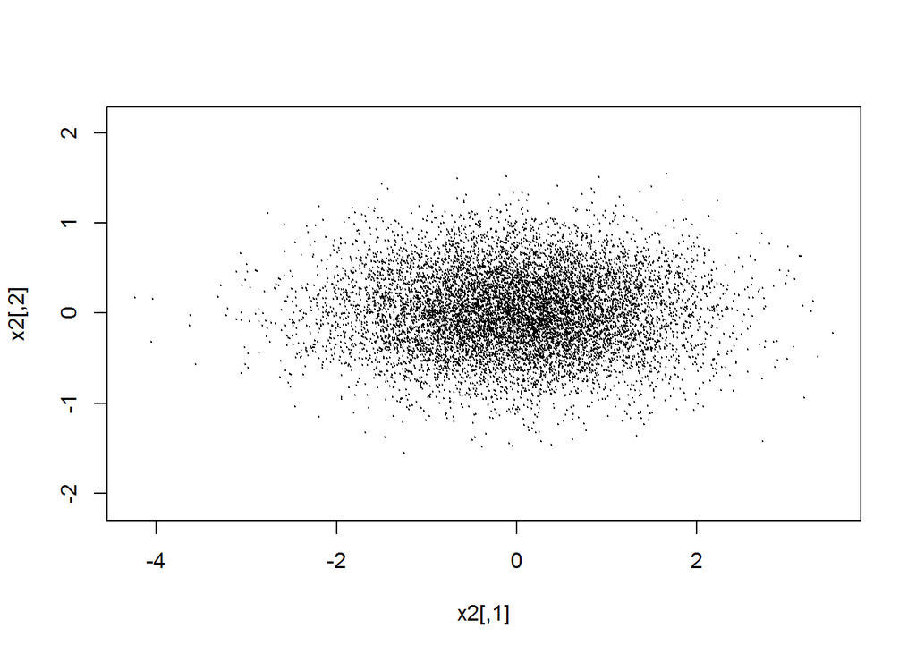

```r
plot(x2,asp=TRUE,pch=20,cex=0.1)
```

# 9 多次元の任意な分布

## 9.1 Exercise 4

次のようにして生成される、多変量の観察データ x があったとする。

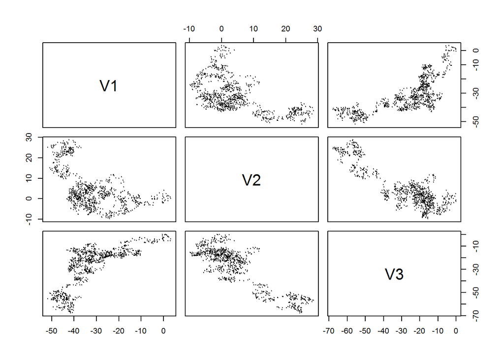

```r
d <- 3
n <- 1000
x <- matrix(rnorm(d*n),ncol=d)
x <- apply(x,2,cumsum)

plot(as.data.frame(x),pch=20,cex=0.1)
```

```r
plot3d(x)
```

[interactive chart not shown]

## 9.2 Exercise 4-1

xの各変数の標本平均を求めよ。 xの分散共分散行列を求めよ。

```
## [1] -31.912746   4.501103 -27.623215
```

```
##           [,1]       [,2]      [,3]
## [1,] 129.75955  -57.61427  140.0478
## [2,] -57.61427   84.32553 -131.9892
## [3,] 140.04775 -131.98923  279.8988
```

## 9.3 Exercise 4-2

4-1 で求めた平均値ベクトルと分散共分散行列とに基づく、多変量正規乱数を発生し、ペアワイズにプロットせよ。

[interactive chart not shown]

[interactive chart not shown]

## 9.4 Exercise 4-3

回転行列を用いて、xを回転し(軸を取り直し)、その標本平均と分散共分散行列とを求め、4-1のそれと比較せよ。

各変数の平均も分散も異なることを確かめよ。

```
## [1] "mean x"
```

```
## [1] -31.912746   4.501103 -27.623215
```

```
## [1] "mean x rotated"
```

```
## [1]  14.921155 -39.554673  -3.809494
```

```
## [1] "cov x"
```

```
##           [,1]       [,2]      [,3]
## [1,] 129.75955  -57.61427  140.0478
## [2,] -57.61427   84.32553 -131.9892
## [3,] 140.04775 -131.98923  279.8988
```

```
## [1] "cov x rotated"
```

```
##          [,1]      [,2]     [,3]
## [1,] 47.06362  16.88131 21.41078
## [2,] 16.88131 401.27447 89.98056
## [3,] 21.41078  89.98056 45.64576
```

## 9.5 Exercise 4-4

分散は異なるが、分散の和は変わっていないことを、分散共分散行列のトレースを計算することで確かめよ。

同様に、分散共分散行列の固有値の和としてトレースを計算することでも確かめよ。

```
## [1] 493.9838
```

```
## [1] 493.9838
```

```
## [1] 493.9838
```

```
## [1] 493.9838
```

## 9.6 Exercise 4-5

データセットxの軸の取り方を回転することによって変えても、各軸の分散の和は変わらない。 分散の和は変わらないが、分散の総和の分配具合は変わる。

そのことを、多数の回転行列をランダムに発生させ、データセットを回転した上で各軸方向の分散を計算し、その分散の値を大小順序でソートしてプロットし、分配具合が変わることを具体的に確認せよ。

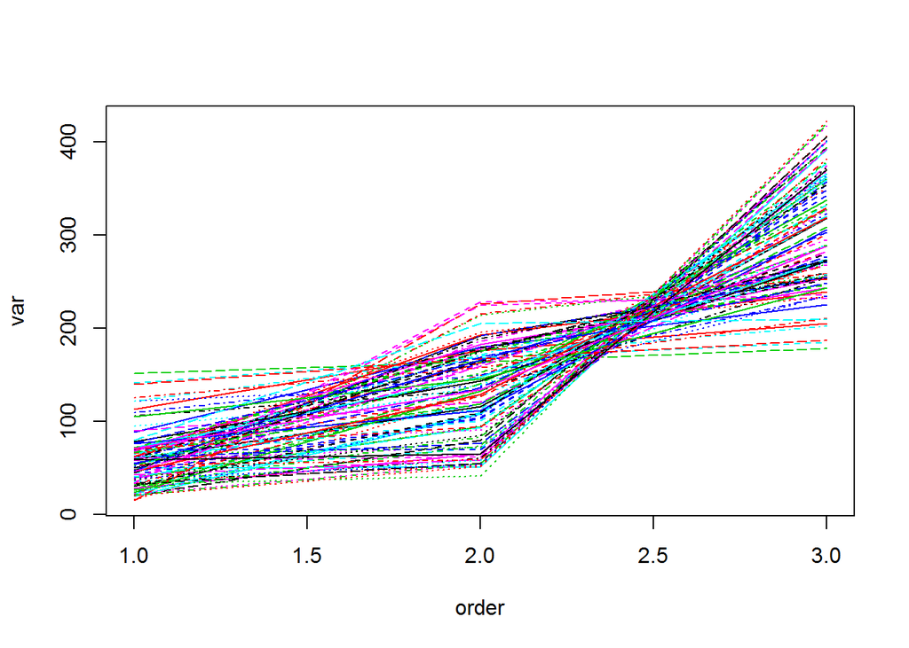

## 9.7 Exercise 4-6

xの分散共分散行列の固有値を求めることで、分散共分散行列を対角化するような回転をしたときの、各軸の分散を求めることができる。

その分散を4-4のプロットに重ねてプロットせよ。

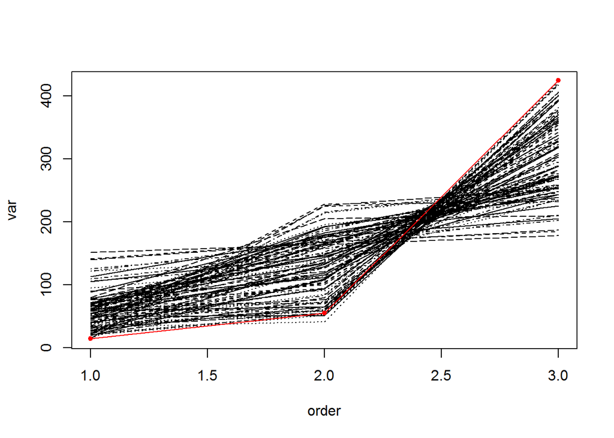

## 9.8 Exercise 4-7

4-4,4-5と同様のプロットを変数の数を増やして実施せよ。

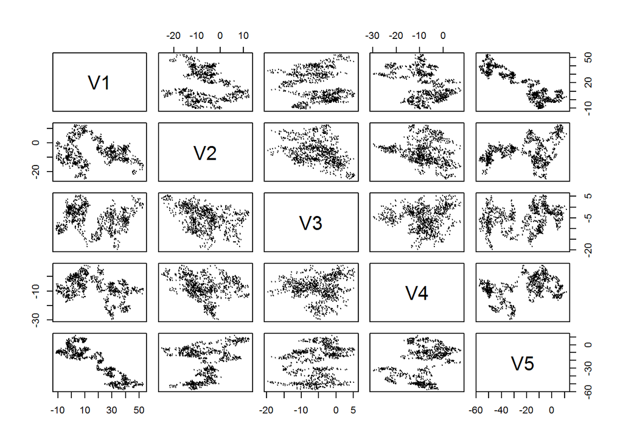

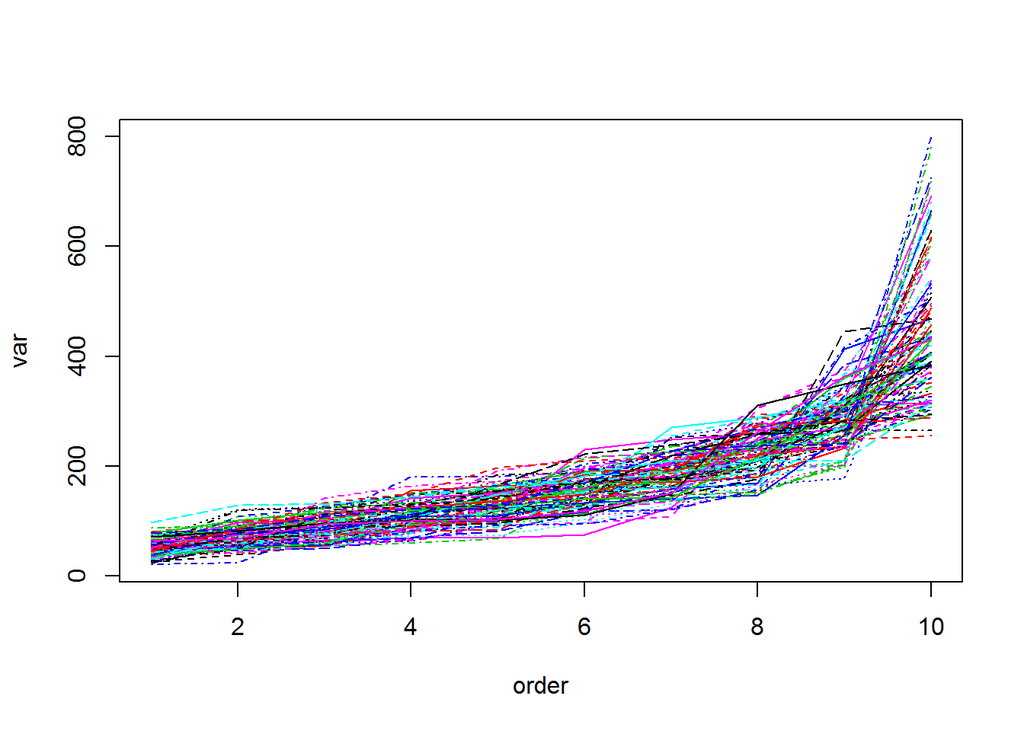

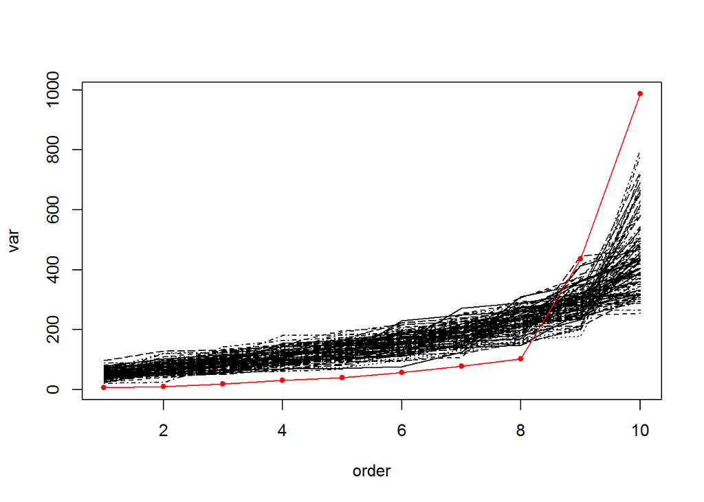

```r
d <- 10
n <- 1000
x <- matrix(rnorm(d*n),ncol=d)
x <- apply(x,2,cumsum)

plot(as.data.frame(x[,1:5]),pch=20,cex=0.1)
```